### Multivariate Stochastic Volatility Using Discount Factors and Optimal Portfolio Decisions

#### Michael Ellis

> - Email: michaelellis003@gmail.com
> - LinkedIn: www.linkedin.com/in/michaelellis003
> - Website: michaelellis003.github.io

#### References

> - Section 10.4 of Time Series Modeling, Computation, and Inference (Prado and West, 2010)
> - Portfolio Selection: Efficient Diversification of Investments (Markowitz, 1959)
> - The code for this project can be found on my GitHub [here](https://github.com/michaelellis003/stochastic_volatility)

#### Stochastic Volatility

> In a [previous post](https://michaelellis003.github.io/files/filtering_blog.html) I discussed sequential inference for multivariate dynamic linear models with unknown fixed observation variances and covariances. This assumption is often too restrictive. For example, it is common for the variance of stock prices to vary through time. Estimating the changing variance and covariance of an asset or group of assets can be helpful in pricing the assets and managing risk. A classic example is portfolio optimization – how to “weight” a collection of assets in order to maximum expected returns while minimizing a given level of financial risk. For this post I will continue the discuss of sequential inference for multivariate dynamic linear models using discount factors by allowing for time varying observation covariance matrices.

> Recall the multivariate DLM (now with unknown time varying observation covariance matrix $\mathbf{\Sigma_t}$),
> $$\begin{align}
> \mathbf{y'_t} &= \mathbf{F'_t} \mathbf{ \Theta_t} + \mathbf{\nu'_t} \hspace{1cm} \mathbf{\nu_t} \sim N(0, v_t \mathbf{\Sigma_t}) \\
> \mathbf{\Theta_t} &= \mathbf{G_t} \mathbf{ \Theta_{t-1}} + \mathbf{\Omega_t} \hspace{1cm} \mathbf{\Omega_t} \sim N(0, \mathbf{W_t}, \mathbf{\Sigma_t}).
> \end{align}$$

#### A discount factor approach to modeling stochastic volatility

> This discussion follows along with section 10.4 of Prado and West (2010). At time $t-1$, we assume an inverse Wishart marginal posterior for the observation covariance matrix, $\mathbf{\Sigma_{t-1}} \sim IW(n_{t-1}, \mathbf{D_{t-1}})$. Given posterior of $\mathbf{\Sigma_{t-1}}$ at time $t-1$ we can allow $\mathbf{\Sigma_{t-1}}$ to vary as time transitions to $t$ using a discount factor to produce a random walk type behavior.

> At time $t$, let the prior of covariance matrix $\mathbf{\Sigma_{t}}$ given observations $\mathbf{y_{1:t-1}}$ be given by,
> $$\begin{align}
> [ \mathbf{\Sigma_t} | \mathbf{y_{1:t-1}}] \sim IW(\beta h_{t-1} - q + 1, \beta \mathbf{D_{t-1}})
> \end{align}$$
> where $\beta \in (0,1]$ is the discount factor and $h_{t-1} = n_{t-1} + q - 1$. You can see that to construct this prior we have “discounted” the parameters of the $t-1$ posterior of $\mathbf{\Sigma_{t-1}}$. Notice, the expected location stays the same but the variance is increased, this gives the movement of the $\mathbf{\Sigma_{t}}$ through time a random walk like behavior. Given the posterior of the covariance matrix at time $t-1$ and the prior at time $t$ we can update to the time $t$ posterior of $\mathbf{\Sigma_{t}}$ sequentially, in closed form, each time we receive a new observation. If you are not familiar with the multivariate filtering equations then it might be a good idea to review them [here](https://michaelellis003.github.io/files/filtering_blog.html). At time $t$, the marginal priors, $[ \mathbf{\Sigma_t} | \mathbf{y_{1:t-1}}]$ and $[\Theta_{t-1} | y_{1:t-1}]$ imply a joint prior of
> $$\begin{align}
> [ \Theta_{t-1}, \mathbf{\Sigma_t} | \mathbf{y_{1:t-1}}] \sim N(\mathbf{M_{t-1}}, \mathbf{C_{t-1}}, \beta h_{t-1} - q + 1, \beta \mathbf{D_{t-1}}).
> \end{align}$$

> Our goal is to update to the joint posterior to $[ \Theta_{t}, \mathbf{\Sigma_t} | \mathbf{y_{1:t}}]$ when we receive a new observation at time $t$.
> - Step 1: Update the prior to $[ \mathbf{\Theta_t}, \mathbf{\Sigma_t} | \mathbf{y_{1:t-1}} ]$.
>   $$\begin{align}
>   \mathbf{a_t} = \mathbf{G_t}\mathbf{M_{t-1}} &\hspace{1cm}
>   \mathbf{R_t} = \mathbf{G_t} \mathbf{C_{t-1}} \mathbf{G^{'}_t} + \mathbf{W_t} \\
>   [ \mathbf{\Theta_t}, \mathbf{ \Sigma_t } | \mathbf{y_{1:t-1}} ] &\sim NIW(\mathbf{a_t}, \mathbf{R_t}, \beta h_{t-1} - q + 1, \beta \mathbf{D_{t-1}}) \\
>   \end{align}$$
> - Step 2: Update the one-step-ahead predictive distribution, $[\mathbf{y_t} | \mathbf{y_{1:t-1}}]$.
>   $$\begin{align}
>   \mathbf{f_t} = \mathbf{F'_t} \mathbf{a_t} \hspace{1cm}
>   q_t &= \mathbf{F'_t} \mathbf{R_t} \mathbf{F_t} + v_t \hspace{1cm} \mathbf{S_{t-1}} = \frac{\mathbf{D_{t-1}}}{h_{t-1} - q + 1}\\
>   [\mathbf{y_t}|\mathbf{y_{1:t-1}}] &\sim T_{\eta_{t-1}}(\mathbf{f_t}, q_t \mathbf{S_{t-1}}) \\
>   [\mathbf{y_t}| \mathbf{\Sigma_t}, \mathbf{y_{1:t-1}}] &\sim N(\mathbf{f_t}, q_t \mathbf{\Sigma_t}).
>   \end{align}$$
> - Step 3: Update the joint posterior (filtering) distribution $[\mathbf{\Theta_t}, \mathbf{\Sigma_t} | \mathbf{y_{1:t}}]$ using the new observation $\mathbf{y_t}$.
>   $$\begin{align}
>   \mathbf{M_t} = \mathbf{a_t} + \mathbf{R_t} \mathbf{F_t}\mathbf{e'_t} / q_t \hspace{1cm}
>   &\mathbf{C_t} = \mathbf{R_t} - \mathbf{R_t} \mathbf{F'_t} \mathbf{F_t} \mathbf{R_t} / q_t \hspace{1cm}
>   n_t = \beta h_{t-1} - q + 2 \hspace{1cm} \mathbf{D_t} = \beta \mathbf{D_{t-1}} + \mathbf{e_t} \mathbf{e'_t} / q_t\\
>   &[\mathbf{\Theta_t}, \mathbf{\Sigma_t} | \mathbf{y_{1:t}} ] \sim NIW(\mathbf{m_t}, \mathbf{C_t}, n_t, \mathbf{D_t}) \\
>   \end{align}$$

#### An example

> Below are plots of the percent returns for a subset of stocks currently in the S&P 500 Index from January 2nd of 2009 to May 20th 2019. Let $P_t$ be the closing price at time $t$ then the return at time $t$ is given by $y_t = \frac{(P_t - P_{t-1})}{P_{t-1}} 100$. Looking at the plots below you can see the changing variance of the returns changing through time of each of the stocks and further the stocks appear to normally be in similar states of volatility. For example, all three stocks appear to be in a state of high volatility toward the end of 2018.

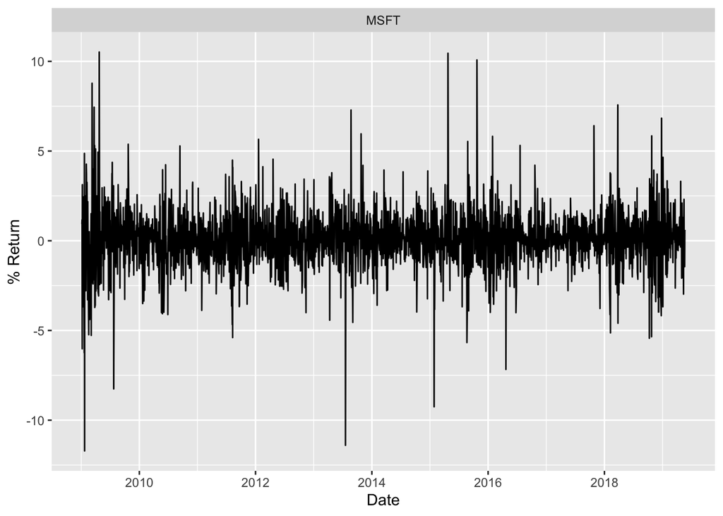

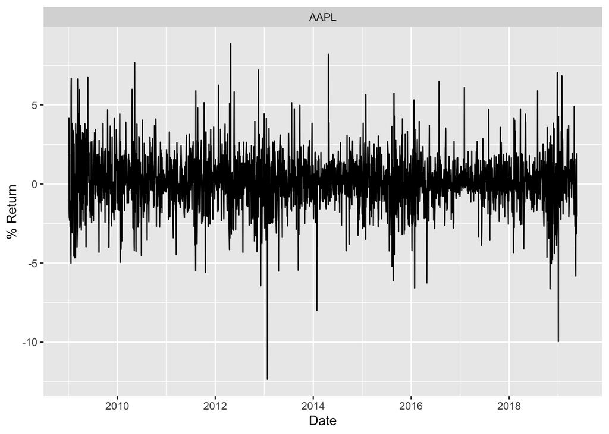

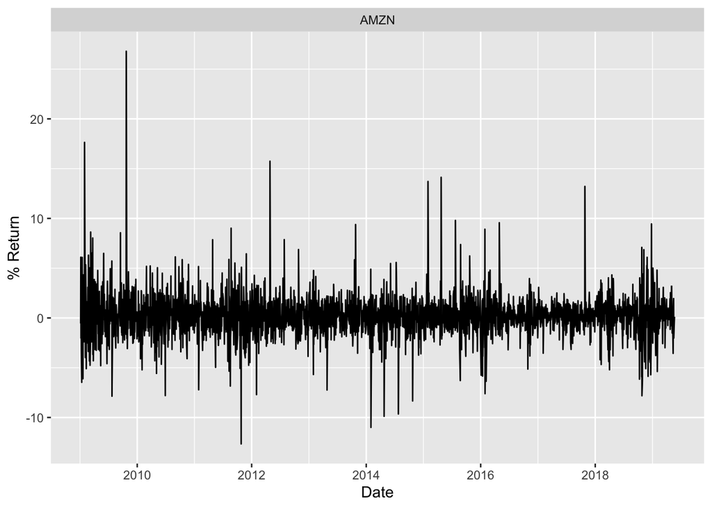

> For our example we will use the model outlined in Section 10.4.6 of Time Series Modeling, Computation, and Inference (Prado and West, 2010). Essentially, we will assume that each series is on a random walk (to track the small random deviations from zero in the expected return) with a time varying variance. For each time series $i=1,2, ..., m$,
> $$\begin{align}
> y_{i,t} &= \mu_{i,t} + \nu_{i,t} \hspace{1cm} \nu_t \sim N(0, \sigma_{\nu_{i,t}}) \\
> \mu_{i,t} &= \mu_{i,t-1} + \omega_{i,t} \hspace{1cm} \omega_t \sim N(0, \sigma_{\omega_{i,t}})
> \end{align}$$
> The model in multivariate form, allowing for time varying covariances between series, is given by
> $$\begin{align}
> \mathbf{y_{t}} &= \mathbf{\theta_{t}} + \mathbf{\nu_{t}} \hspace{1cm} \mathbf{\nu_t} \sim N(0, \mathbf{\Sigma_{t}}) \\
> \mathbf{\theta_{t}} &= \mathbf{\theta_{t-1}} + \mathbf{\omega_{t}} \hspace{1cm} \mathbf{\omega_t} \sim N(0, w_t \mathbf{\Sigma_{t}})
> \end{align}$$

> where the state, $\mathbf{\theta^{'}_t} = (\mu_{1,t}, \mu_{2,t}, \dots, \mu_{m,t})^{'}$, is a vector, $\mathbf{F_t} = 1$, and $\mathbf{G_t} = \mathbf{I}$. The parameter $w_t$ is a scalar and can be specified using a discount factor.

> We will use the model and filtering equations above to determine how to optimally weight an example portfolio of 10 stocks within the S&P 500 (Symbols - AAPL, AMZN, BRB-B, GOOG, GOOGL, JPM, MSFT, PG, V, XOM). I am not claiming this is a good or bad portfolio, it is just an example! In the filtering equations above step 2 provides the one-step-ahead predictive distribution. We can use this forecast to determine how to weight our portfolio. Below are plots of the 90 percent credible intervals from the one-step-ahead predictive distribution and the observed returns for three of the stocks.

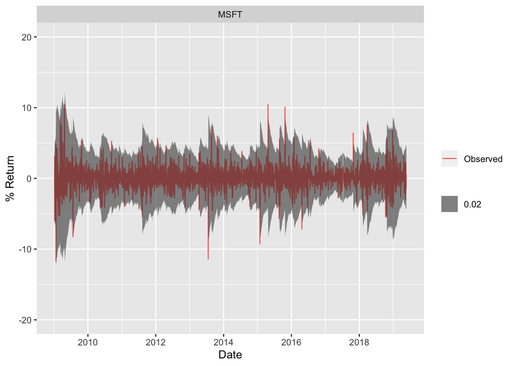

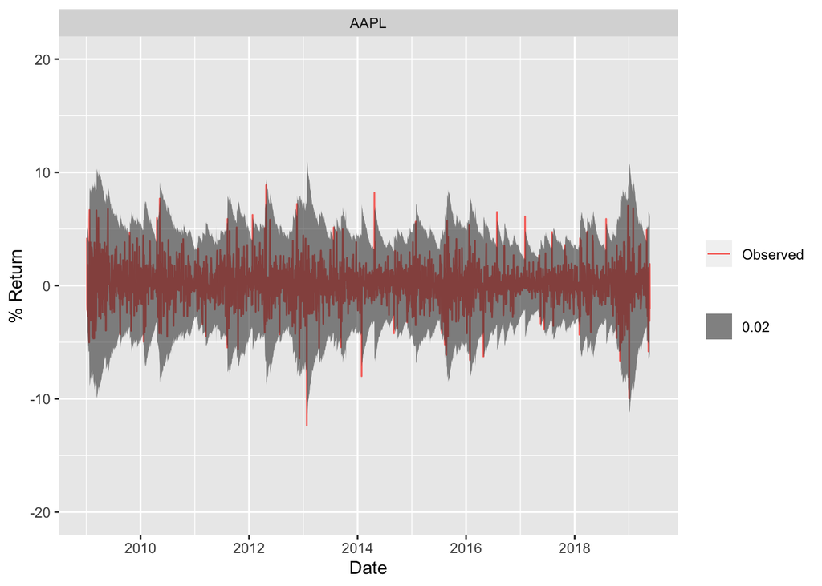

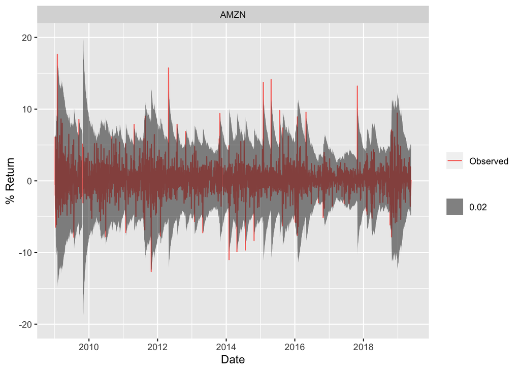

> To find the optimal portfolio weights we will follow along with Section 10.4.7 of Prado and West (2010). Using the optimal portfolio theory of Markowitz (1959), assume at each time step we want a target return of $r_t$. Then the goal is to find a vector of weights, $w_t$, that minimizes the one-step-ahead portfolio variance (i.e. risk) given the constraints $\mathbf{w_t^{'}} \mathbf{f_t} = r_t$ and $\mathbf{w^{'}_t 1} = 1$. At time $t$ the one-step-ahead forecast distribution is Student-T with mean and variance,

> $$\begin{align}
> \mathbf{f_t} = \mathbf{m_{t-1}} \hspace{1cm} \mathbf{V_t} = q_t \mathbf{S_{t-1}} (\beta h_{t-1}/ (\beta h_{t-1} - 2)).
> \end{align}$$
> Then given a target return of $r_t$, the weights that minimize the portfolio variance subject to the constraints are given by,
> $$\begin{align}
> \mathbf{w_t} &= \mathbf{V^{-1}_t}(u_t \mathbf{f_t} + z_t \mathbf{1}) \\
> u_t = \mathbf{1'} \mathbf{V^{-1}_t} \mathbf{g_t} &\hspace{1cm} z_t = -\mathbf{f^{'}_t} \mathbf{V^{-1}_t} \mathbf{g_t} \\
> \mathbf{g_t} = (\mathbf{1}r_t - \mathbf{f_t})/d_t &\hspace{1cm} d_t = (\mathbf{1'} \mathbf{V^{-1}_t} \mathbf{1})(\mathbf{f^{'}_t \mathbf{V^{-1}_t} \mathbf{f_t}}) -
> (\mathbf{1'} \mathbf{V^{-1}_t} \mathbf{f_t})^2.
> \end{align}$$

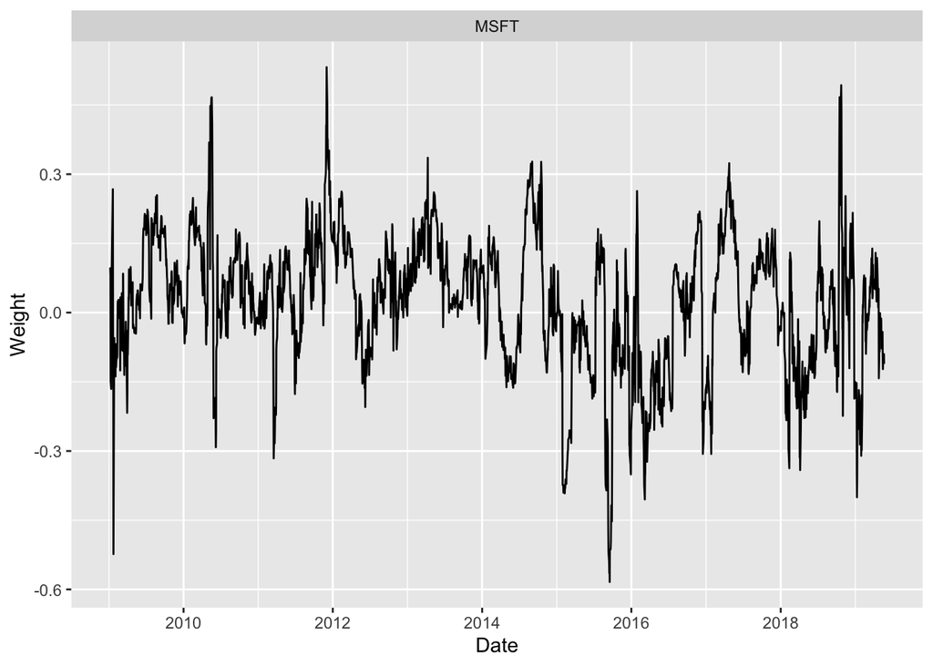

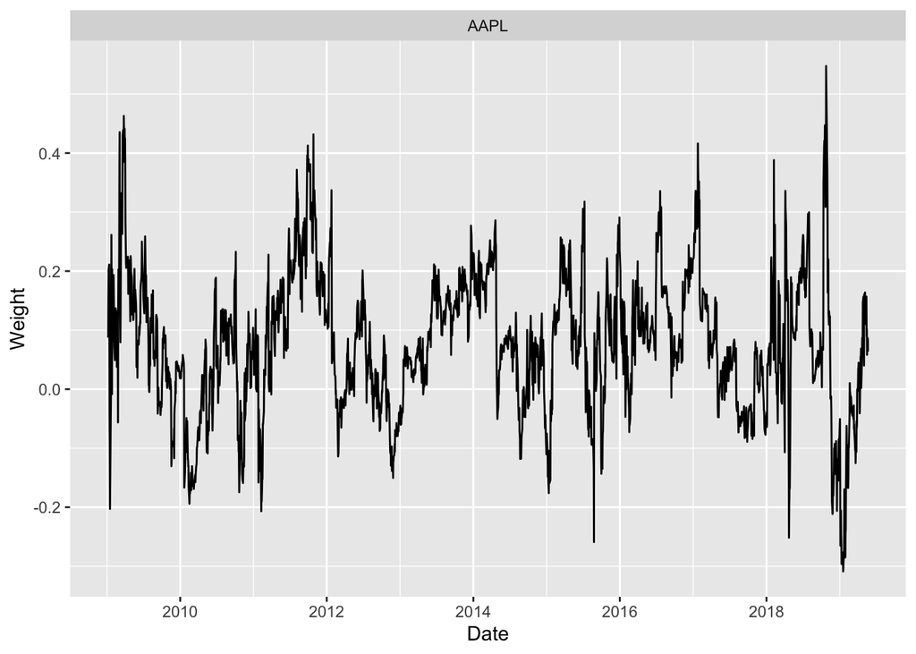

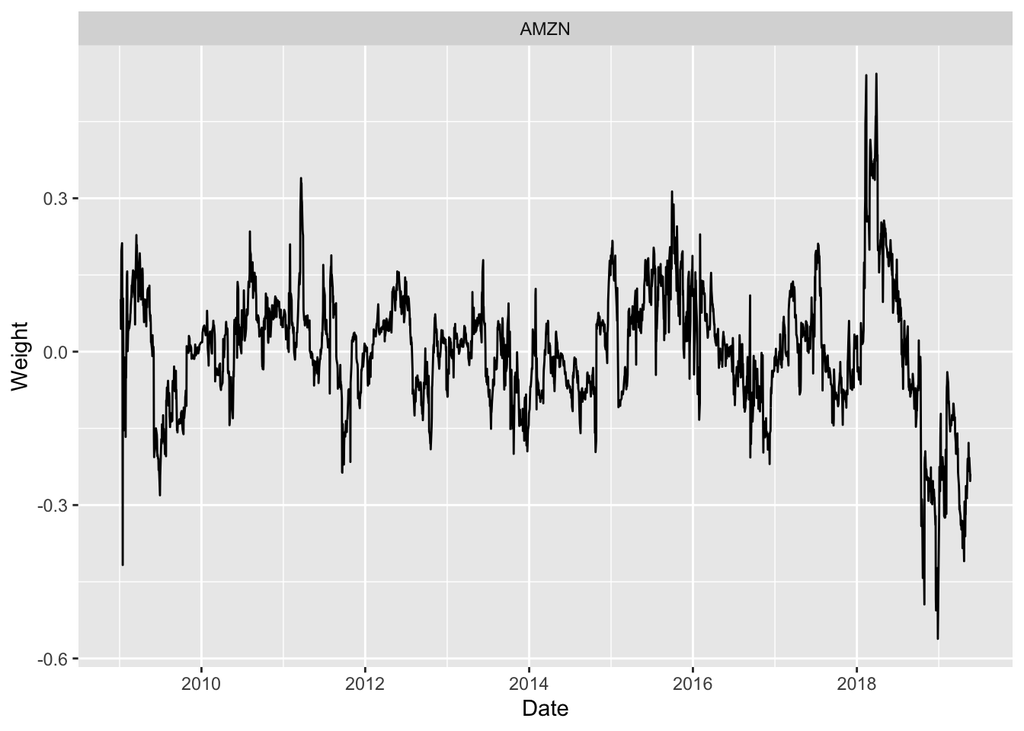

> We can also look at the cumulative returns along with the daily portfolio risk.

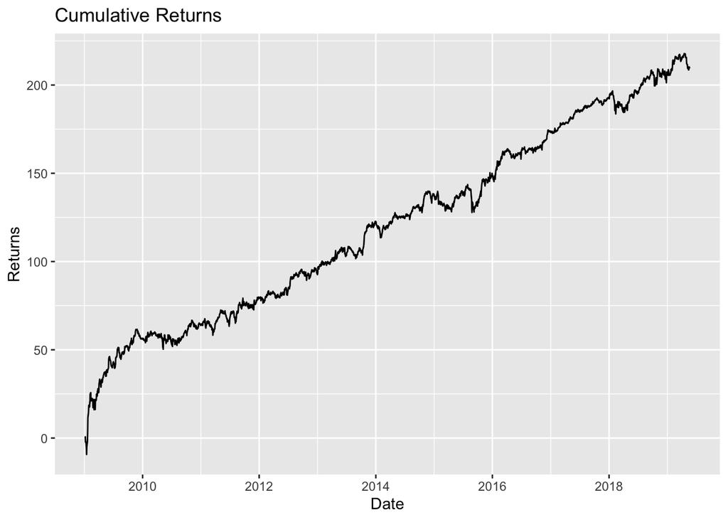

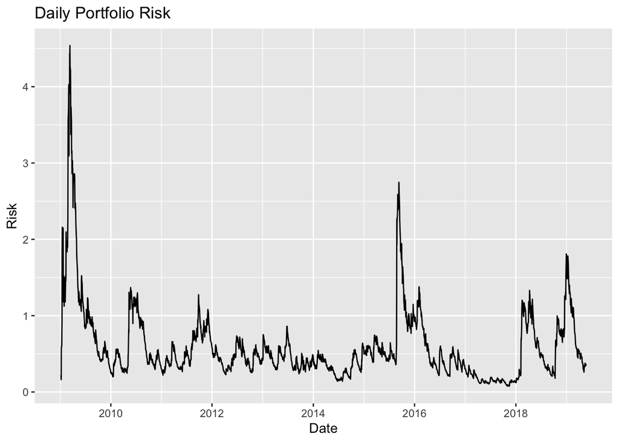

> You can see estimating expected variance can be incredibly helpful when making decisions under deep uncertainty! Full Bayesian inference and forecasting allows us to estimate a distribution of possible outcomes. When making decision we can search over these possible outcomes to find the outcome that maximizes/minimizes our objective function. One issue with the model we used for our example is it is known not the scale well. What if we wanted to find optimal weights for every stock in the S&P 500? An interesting paper discussing scalable multivariate volatility [Bayesian forecasting and scalable multivariate volatility analysis using simultaneous graphical dynamic linear models](https://arxiv.org/abs/1606.08291) (Gruber and West).